# 时序数据预测 - 线性模型

### AR模型：

根据历史观测值预测。C为常数，$\psi_{i}$为待估参数，$\varepsilon_{t}$为误差，P为观察范围

$$ y_{t} = c + \displaystyle\sum_{i=1}^p \psi_{i} * y_{t-i} + \varepsilon_{t} $$

### MA模型

根据历史误差来预测。$\mu$为观测均值，$\psi_{i}$为待估参数，$\varepsilon_{t-i}$为随机误差，满足正态分布

$$ y_{t} = \mu + \displaystyle\sum_{i=1}^p \psi_{i}*\varepsilon_{t-i} + \varepsilon_{t} $$

### ARMA：

$$ y_{t} = c + \varepsilon_{t} + \displaystyle\sum_{i=1}^p \psi_{i} * y_{t-i} + \displaystyle\sum_{j=1}^q \phi_{j} * \varepsilon_{t-j} $$$$ y_{t} - \displaystyle\sum_{i=1}^p \psi_{i} * y_{t-i} = c + \varepsilon_{t} + \displaystyle\sum_{j=1}^q \phi_{j} * \varepsilon_{t-j} $$$$ (1- \displaystyle\sum_{i=1}^p \psi_{i} * L^{i}) * y_{t} = c + (1 - \displaystyle\sum_{j=1}^q \phi_{j} * L^{i}) * \varepsilon_{t} $$

其中$L$为差分操作符，$L^{i} * X_{t} = X_{t-i}$，

### ARIMA

ARMA模型只能用于统计稳定性时间序列数据。但是现实中许多时间序列都表现出非平稳行为，包含趋势（如股价一直在涨）和季节模式的时间序列（不同季节均值不同）本质上也是非平稳的。 因此，从应用程序角度来看，ARMA模型不足以正确描述在实践中经常遇到的非平稳时间序列。从上面的 Dickey-Fuller 检验可以发现，通过应用数据点的有限差分可以使非平稳时间序列平稳。ARIMA模型就是在ARMA基础上增加了差分项。

$$ (1- \displaystyle\sum_{i=1}^p \psi_{i} * L^{i}) * (1 - L)^{i} * y_{t} = c + (1 - \displaystyle\sum_{j=1}^q \phi_{j} * L^{i}) * \varepsilon_{t} $$

这里差异算子 $(1 - L)^{i} * X_{t} = \nabla^{i} * X_{t} = \nabla (\nabla^{i-1} * X_{t}) = (X_{t} - X_{t-1}) - (X_{t-1} - X_{t-2}) - ...$，可以理解为`pd.DataFrame().diff().diff()`。所以ARIMA模型先对输入序列做`i`次DIFF，然后再用ARMA求解。

$ARIMA(q,d=0,q) == ARMA(q, q) $，$ARIMA(0,1,0) : y_{t} = y_{t-1} + \varepsilon_{t}$

```python
%matplotlib inline
```

```python
# from IPython.core.display import display, HTML
# display(HTML("<style>.container { width:90% !important; }</style>"))

import matplotlib.pyplot as plt
large = 22; med = 16; small = 12
params = {'axes.titlesize': large,
          'legend.fontsize': med,
          'figure.figsize': (16, 6),
          'axes.labelsize': med,
          'axes.titlesize': med,
          'xtick.labelsize': med,
          'ytick.labelsize': med,
          'figure.titlesize': large}
plt.rcParams.update(params)
plt.style.use('seaborn-whitegrid')


import sys
sys.path.append('/Users/chenfei/Workspace/stocks')
import math

import pandas as pd
import numpy as np
import scipy

from sklearn.metrics import mean_squared_error, mean_absolute_error
import statsmodels as sm
import statsmodels.tsa.stattools as stattools
from statsmodels.tsa.seasonal import seasonal_decompose
from statsmodels.tsa.statespace.sarimax import SARIMAX
from statsmodels.graphics.tsaplots import plot_acf, plot_pacf

from dataset.api import gtja_datasource
from dataset import calendars
```

```python
# 获取沪深300指数K线数据
price = gtja_datasource.get_price(['000300.XSHG'], end_date='2020-04-10', start_date='2007-01-01')

price = price.reset_index('symbol', drop=True)
price = price.asfreq("B", method='pad')
month_bar = price.close.asfreq('M').fillna(method='pad')
```

```python
def plot_adfuller(values):
    values = values.dropna()
    orig = plt.plot(values, color='blue',label='Values')
    mean = plt.plot(values.rolling(5).mean(), color='red', label='MA5')

    plt.legend(loc='best')
    plt.title('Timeseries & MA5')
    plt.show()

    adtests = stattools.adfuller(values, autolag='AIC')
    s = pd.Series(adtests[0:4], index=['T-test', 'p-value', 'Lags used', 'Observations Used'])
    for k, v in adtests[4].items():
        s['Critical Value (%s)' % k] = v
    print(s)

def plot_corr(timeseries, nlags=25):
    fig, ax = plt.subplots(nrows=1, ncols=2, figsize=(20, 4))
    plot_acf(timeseries, lags=nlags, ax=ax[0])
    plot_pacf(timeseries, lags=nlags, ax=ax[1])
    plt.show()

def plot_prediction(model, train, test):
    fitted = model.fit()
    print(fitted.summary())

    fitted.plot_diagnostics()

    fig, ax = plt.subplots()
#     ax = train.plot(ax=ax, color='gray', label='Train')
    ax = test.plot(ax=ax, color='blue', label='Test')

#     predict_results = fitted.get_prediction(start=train.index[5], end=train.index[-1], dynamic=True)
#     predict_df = predict_results.summary_frame(alpha=0.1)
#     predict_df['mean'].plot(ax=ax, color='orange', label='Train Predict')

    predict_results = fitted.get_prediction(start=test.index[0], end=test.index[-1], dynamic=True)  # 95% confidence
    predict_df = predict_results.summary_frame(alpha=0.4)
    predict_df['mean'].plot(ax=ax, color='green', label='Test Predict')
    ax.fill_between(predict_df.index, predict_df['mean_ci_lower'], predict_df['mean_ci_upper'], color='k', alpha=.04)
    plt.legend(loc='best', fontsize=8)
    plt.show()
```

## 时间序列分析中的平稳性问题

首先平稳性是指时间序列的统计性质关于时间平移的不变性。严格平稳需要所有的统计性质都是关于时间平移不变的，而弱平稳只需要一阶矩与二阶矩(以及协方差)是时间平移不变的。时间序列平稳性的意义在于可以通过历史数据的性质来得到其未来的一些预测，如果时间序列不是平稳的，由历史数据得到的统计性质对未来毫无意义。

可以通过 Dickey-Fuller 检验来确定时序数据是否具备平稳性，如果`p-value`小于5%，则可以认为具有平稳性。对于不平稳对数据可以通过如下办法进行处理：

- Deflation by CPI: 减去通货膨胀率或者指数
- Logarithmic: 取对数
- First Difference: 把值转换成环比变化率，对于ARIMA模型并不需要显示DIFF
- Seasonal Difference: 把值转换成同比变化率
- Seasonal Adjustment: 没搞懂

假如序列有显著是季节性模式，则需要用季节性差分，但是不要使用两次季节性差分或总过超过两次差分（季节性和非季节性） 假如差分序列在滞后s处有正的ACF，s是季节的长度，则需要加入SAR项；假如差分序列在滞后s处有负的ACF，则需要加入SMA项，如果使用了季节性差异，则后一种情况很可能发生，如果数据具有稳定和合乎逻辑的季节性模式。如果没有使用季节性差异，前者很可能会发生，只有当季节性模式不稳定时才适用。应该尽量避免在同一模型中使用多于一个或两个季节性参数（SAR + SMA），因为这可能导致过度拟合数据和/或估算中的问题。

通过ADF验证可以发现，沪深300的股价日线并具备平稳性，这是不是从一个侧面验证了股价是随机游走的。通过对日线做`First Difference`，显示出较好的平稳性。并且日线图显示季节性基本处于白噪声状态，也就是说每日价格可能跟历史任一时刻都有关（也都无关）。但是月线表现出较好都平稳性，并且季节性表现出较好都规律性。

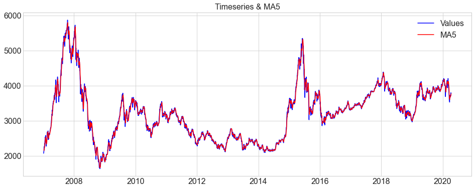

```
T-test                    -2.770858
p-value                    0.062559
Lags used                 29.000000
Observations Used       3432.000000
Critical Value (1%)       -3.432257
Critical Value (5%)       -2.862383
Critical Value (10%)      -2.567218
dtype: float64
```

```python
# 日线ADF检验
plot_adfuller(price.close)
```

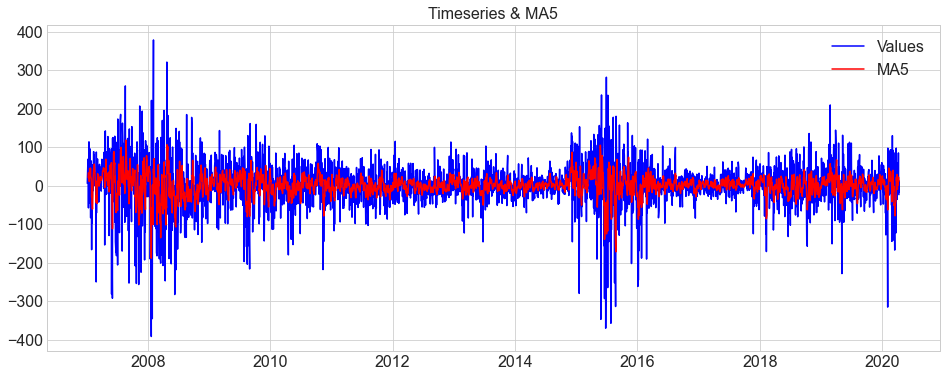

```
T-test                 -1.012585e+01
p-value                 9.186120e-18
Lags used               3.000000e+01
Observations Used       3.430000e+03
Critical Value (1%)    -3.432258e+00
Critical Value (5%)    -2.862383e+00
Critical Value (10%)   -2.567219e+00
dtype: float64
```

```python
# 日线一介差分ADF检验
plot_adfuller(price.close.diff(1))
```

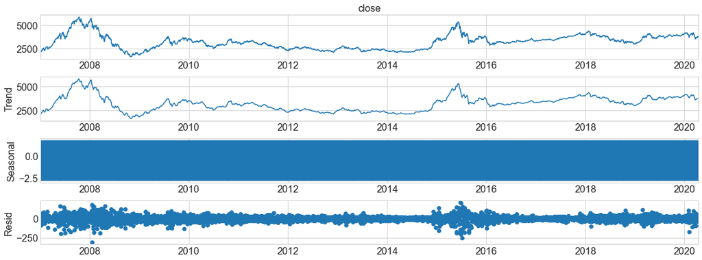

```python
result = seasonal_decompose(x=price.close)
result.plot()
plt.show()
```

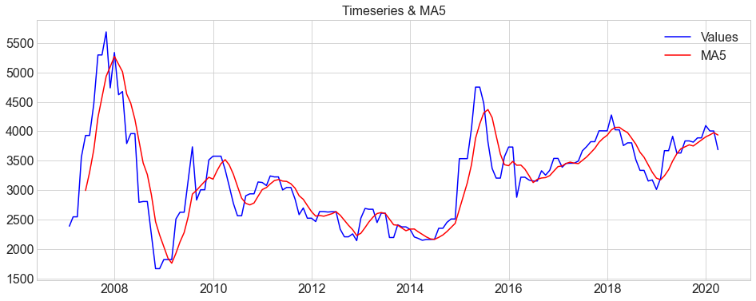

```
T-test                   -3.932884
p-value                   0.001806
Lags used                 4.000000
Observations Used       154.000000
Critical Value (1%)      -3.473543
Critical Value (5%)      -2.880498
Critical Value (10%)     -2.576878
dtype: float64
```

```python
plot_adfuller(month_bar)
```

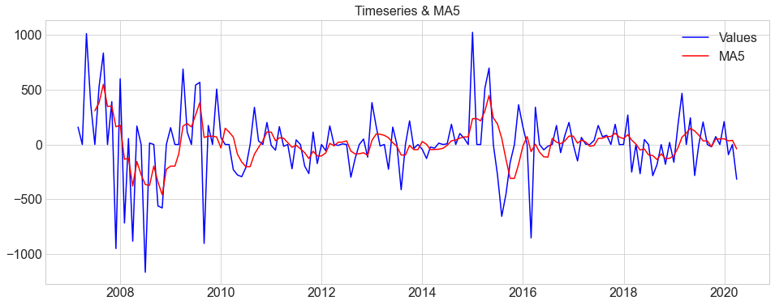

```
T-test                   -5.630480
p-value                   0.000001
Lags used                13.000000
Observations Used       144.000000
Critical Value (1%)      -3.476598
Critical Value (5%)      -2.881829
Critical Value (10%)     -2.577589
dtype: float64
```

```python
plot_adfuller(month_bar.diff().dropna())
```

```
count     147.000000
mean     3163.639221
std       605.039434
min      2246.777083
25%      2550.599375
50%      3179.352500
75%      3610.561250
max      4644.540417
Name: trend, dtype: float64
```

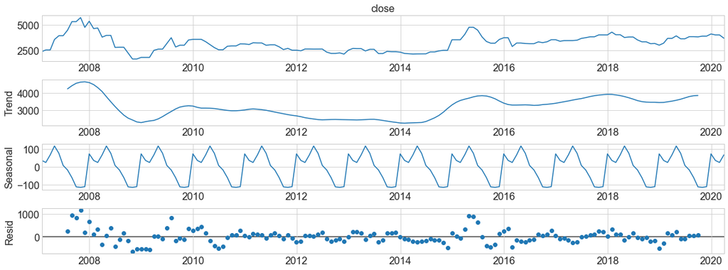

```python
seasonal_result = seasonal_decompose(month_bar)
print(seasonal_result.trend.describe())
seasonal_result.plot()
plt.show()
```

### SARIMA的阶数：(p, d, q)，(P, D, Q, s)

通过自相关函数(ACF)和偏自相关函数(PACF)可以确定`p`和`q`。自相关系数有两种情况：1. 截尾：相关系数在p阶之后变为0；拖尾：相关系数按指数衰减（或成正弦波形式)。若平稳序列的PACF是截尾的，而ACF是拖尾的，可断定序列适合AR模型；若平稳序列的PACF是拖尾的，而ACF是截尾的，则可断定序列适合MA模型；若平稳序列的PACF和ACF均是拖尾的，则序列适合ARMA模型。`arma_order_select_ic`函数可以自动判断合适的`p`和`q`值。

`d`一般情况下为1就够用了，从上面ADF检验也可以看出，`diff`之后的价差序列满足统计稳定性条件。statsmodel中的`x13.x13_arima_select_order`可以用来搜索最佳p, d, q，不过它依赖x12或x13，不过暂时没搞定。替代方案可以用`scipy`的`optimize`，寻找使得模型的AIC（或BIC）最小的一组参数。不过选出的q, q与`arma_order_select_ic`不一致。

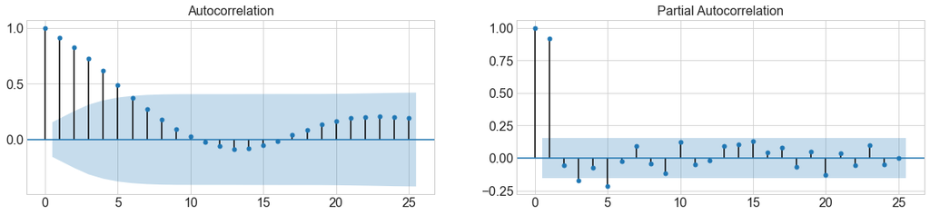

```
Trend AIC (3, 4)
Trend BIC (1, 0)
```

```python
plot_corr(month_bar, nlags=25)

trend_evaluate = stattools.arma_order_select_ic(month_bar, ic=['aic', 'bic'], trend='nc', max_ar=4, max_ma=4)
print('Trend AIC', trend_evaluate.aic_min_order)
print('Trend BIC', trend_evaluate.bic_min_order)
```

```python
def target_func(orders):
    try:
        fit = SARIMAX(endog=month_bar, trend='n', order=(1, 1, 0), seasonal_order=orders).fit()
        return fit.bic
    except:
        return np.inf

from scipy.optimize import brute
grid = (slice(0, 4, 1), slice(0, 2, 1), slice(0, 4, 1), slice(2, 6, 1))
brute(target_func, grid, finish=None)
```

```
array([0., 1., 1., 5.])
```

```
                                      SARIMAX Results
===========================================================================================
Dep. Variable:                               close   No. Observations:                  135
Model:             SARIMAX(1, 1, 0)x(0, 1, [1], 5)   Log Likelihood                -939.938
Date:                             Thu, 21 May 2020   AIC                           1885.876
Time:                                     17:03:09   BIC                           1894.455
Sample:                                 01-31-2007   HQIC                          1889.362
                                      - 03-31-2018
Covariance Type:                               opg
==============================================================================
                 coef    std err          z      P>|z|      [0.025      0.975]
------------------------------------------------------------------------------
ar.L1          0.0106      0.075      0.142      0.887      -0.136       0.157
ma.S.L5       -0.9988      5.933     -0.168      0.866     -12.627      10.629
sigma2       1.11e+05   6.54e+05      0.170      0.865   -1.17e+06    1.39e+06
===================================================================================
Ljung-Box (Q):                       32.60   Jarque-Bera (JB):                36.39
Prob(Q):                              0.79   Prob(JB):                         0.00
Heteroskedasticity (H):               0.43   Skew:                            -0.66
Prob(H) (two-sided):                  0.01   Kurtosis:                         5.25
===================================================================================

Warnings:
[1] Covariance matrix calculated using the outer product of gradients (complex-step).
```

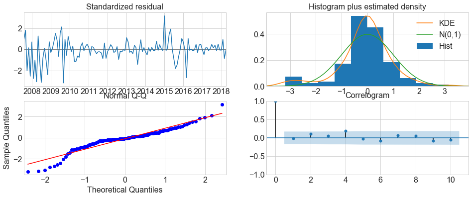

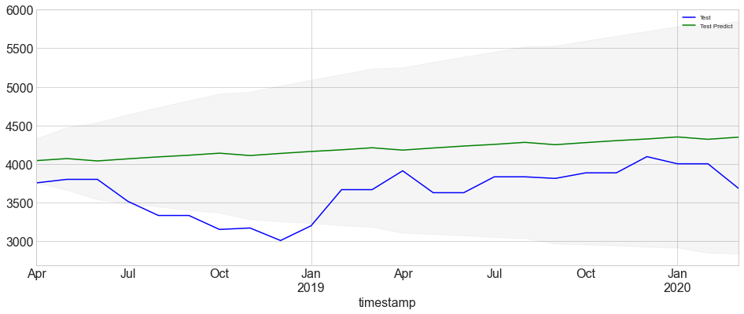

```python
# 验证一下SARIMAX模型的预测能力

train_data = month_bar.iloc[:-24]
test_data = month_bar.iloc[-24:]
sarimax = sm.tsa.statespace.sarimax.SARIMAX(endog=train_data, trend='n', order=(1,1,0), seasonal_order=(0,1,1,5))
plot_prediction(sarimax, train_data, test_data)
```

#### 参考文献

- [1] Tsay, R. S. and Tiao, G. (1984). “Consistent estimates of autoregressive parameters andextended sample autocorrelation function for stationary and nonstationary ARMA
- [2] An Introductory Study on Time Series Modeling and Forecasting
- [3] [Summary of rules for identifying ARIMA models](http://people.duke.edu/~rnau/arimrule.htm)
- [4] [Data transformations and forecasting models: what to use and when](http://people.duke.edu/~rnau/whatuse.htm)